# Scatter D3

Anya Steinhart

02 May 2018

`Scatter D3` is a way to create interactive scatter plots by using the`d3.js` java script visualization library. The package provides an HTML widget based on the htmlwidgets package.

```r
#Premliminaries
library(scatterD3)
```

```r
library(ggplot2)
library(TeachingDemos)
#IF we have time
library(networkD3)
char2seed("Anya Steinhart, Ph.D")
```

We will be using the built in package “Iris” by Edgar Anderson. Lets take a look at these data

```r
# This takes up a lot of room so I am commenting it out
#print(iris)
```

This is a pretty large data set. For example’s sake, I am going to cut down these data because it produces a less cluttered graph.

```r
iris2 <- iris[sample(1:nrow(iris),25),]
iris2
```

```
##     Sepal.Length Sepal.Width Petal.Length Petal.Width    Species
## 135          6.1         2.6          5.6         1.4  virginica
## 149          6.2         3.4          5.4         2.3  virginica
## 150          5.9         3.0          5.1         1.8  virginica
## 122          5.6         2.8          4.9         2.0  virginica
## 69           6.2         2.2          4.5         1.5 versicolor
## 102          5.8         2.7          5.1         1.9  virginica
## 130          7.2         3.0          5.8         1.6  virginica
## 127          6.2         2.8          4.8         1.8  virginica
## 8            5.0         3.4          1.5         0.2     setosa
## 67           5.6         3.0          4.5         1.5 versicolor
## 137          6.3         3.4          5.6         2.4  virginica
## 73           6.3         2.5          4.9         1.5 versicolor
## 131          7.4         2.8          6.1         1.9  virginica
## 134          6.3         2.8          5.1         1.5  virginica
## 100          5.7         2.8          4.1         1.3 versicolor
## 75           6.4         2.9          4.3         1.3 versicolor
## 87           6.7         3.1          4.7         1.5 versicolor
## 39           4.4         3.0          1.3         0.2     setosa
## 115          5.8         2.8          5.1         2.4  virginica
## 22           5.1         3.7          1.5         0.4     setosa
## 138          6.4         3.1          5.5         1.8  virginica
## 14           4.3         3.0          1.1         0.1     setosa
## 89           5.6         3.0          4.1         1.3 versicolor
## 24           5.1         3.3          1.7         0.5     setosa
## 111          6.5         3.2          5.1         2.0  virginica
```

Now that that is done, onto making scatter plots!!

```r
#Creating a basic scatter plot
#You can pass data arguments as vectors, or as a separate "data" agrument. I prefer the later
scatterD3(data=iris2, x=Petal.Length, y=Sepal.Length)
```

[interactive chart not shown]

```r
#Adding Y and X axis labels
scatterD3(data=iris2, x=Petal.Length, xlab="Petal Length", y=Sepal.Length, ylab = "Sepal Length")
```

[interactive chart not shown]

```r
#We can also use categorical variables on one the axis
scatterD3(data=iris2,x=Species,y=Petal.Length)
```

[interactive chart not shown]

```r
#you can also alter the margins if the labels are cut
scatterD3(data=iris2,x=Species,y=Petal.Length, left_margin = 80)
```

[interactive chart not shown]

```r
# We can also remove the gear as well if we want
scatterD3(data=iris2, x=Petal.Length, y=Sepal.Length, menu=FALSE)
```

[interactive chart not shown]

Just by this simple command, we can zoom in and out of the plot, pan the plot by dragging the the mouse, and hover over a point to view the x and y coordinates

We can also add variation to our points

```r
#Adding variation to our scatter plots
#Adding color to our graphs
##You can only use specific HTML colors that are supported by browsers,
#Link to compatable colors: https://www.w3schools.com/tags/ref_colornames.asp
scatterD3(data=iris2, x=Petal.Length, y=Sepal.Length, point_size = 30, point_opacity = 0.75, colors = "RebeccaPurple")
```

[interactive chart not shown]

```r
#Changing the hover
scatterD3(data=iris2, x=Petal.Length, y=Sepal.Length,point_size = 30, point_opacity = 1, colors = "RebeccaPurple",  hover_size = 50, hover_opacity = 0.75)
```

[interactive chart not shown]

```r
#Adding labels to the individual points
scatterD3(data=iris2,  x=Petal.Length, y=Sepal.Length,point_size = 30, point_opacity = 1, fixed = TRUE, colors = "RebeccaPurple",  hover_size = 6, hover_opacity = 1,lab=Species, labels_size = 9)
```

[interactive chart not shown]

We can map variables using symbols, colors, size and opacity of the points

```r
#Color- Categorical
scatterD3(data=iris2, x=Petal.Length, y=Sepal.Length, col_var = Species, colors = c("Pink","Plum", "PowderBlue"))
```

[interactive chart not shown]

```r
#Continuous
scatterD3(data=iris2, x=Petal.Length,  y=Sepal.Length, col_var = Sepal.Width, col_continuous = TRUE)
```

[interactive chart not shown]

```r
#shape, just categorical
scatterD3(data=iris2, x=Petal.Length, y=Sepal.Length, symbol_var =Species, col_var=Species)
```

[interactive chart not shown]

```r
#Size and opacity can both be used for continuous
#Size
scatterD3(data=iris2, x=Petal.Length, y=Sepal.Length, colors="Plum", size_var =Sepal.Width,
size_range = c(10, 100))
```

[interactive chart not shown]

```r
#opacity
scatterD3(data=iris2, x=Petal.Length, y=Sepal.Length, colors="Plum", opacity_var = Sepal.Length)
```

[interactive chart not shown]

Adding axis labels and lines into the graph

```r
#Adding lines
scatterD3(data=iris2, x=Petal.Length, y=Sepal.Length, colors="Plum",  lines = data.frame(slope = 0.44, intercept = 4.12, stroke = "Green", stroke_width = 5))
```

[interactive chart not shown]

Add caption

```r
#Adding titles and text
scatterD3(data=iris2, x=Petal.Length, xlab="Petal Length", y=Sepal.Length, ylab = "Sepal Length", col_var = Species, colors = c("Pink","Plum", "PowderBlue"),
          caption=list(title="This is my title",
                       text="This is my text. I do not know what to say here. "))
```

[interactive chart not shown]

```r
#Adding captions to points- this uses java script which I won't pretend to understand but it works
tooltips <- paste( "This is an iris <I dont know what this means>","</strong><br/>with a", iris$Petal.Width, "inch petal width!")
scatterD3(data = iris2, x =Petal.Length, y = Sepal.Length, tooltip_text = tooltips)
```

[interactive chart not shown]

We can add URLs to the points! Among some other cool stuff

```r
#Adding URL
iris2$url <- paste0("https://www.google.com?q=", colnames<-iris2$Species)
scatterD3(data=iris2, x=Petal.Length, y=Sepal.Length, col_var = Species, colors = c("Pink","Plum", "PowderBlue"),url_var=url)
```

[interactive chart not shown]

```r
#Adding a callback, again this uses java script- not showing
scatterD3(data = iris2, x = Petal.Length, y = Sepal.Length,
          click_callback = "function(id, index) {
         alert('scatterplot ID: ' + id + ' - Point index: ' + index)
          }")
```

[interactive chart not shown]

```r
#Adding confident ellipses
scatterD3( data=iris2, x=Petal.Length,y=Sepal.Length, col_var = Species, color= c("Pink","Plum", "PowderBlue"), ellipses=TRUE)
```

[interactive chart not shown]

```r
#Lasso Plug in
scatterD3(data=iris2, x=Petal.Length, y=Sepal.Length, col_var = Species, colors = c("Pink","Plum", "PowderBlue"), lab = Species, lasso=TRUE)
```

[interactive chart not shown]

```r
#Lasso Call back using java script
scatterD3(data=iris2, x=Petal.Length, y=Sepal.Length, col_var = Species, colors = c("Pink","Plum", "PowderBlue"),lab=Species, lasso=TRUE, lasso_callback= "function(sel) {alert(sel.data().map(function(d) {return d.lab}).join('\\n'));}")
```

[interactive chart not shown]

We can intergrate our points into other graphing packages,like ggplot2!

```r
scatterD3(data=iris2, x=Petal.Length, y=Sepal.Length, lab=Species)
```

[interactive chart not shown]

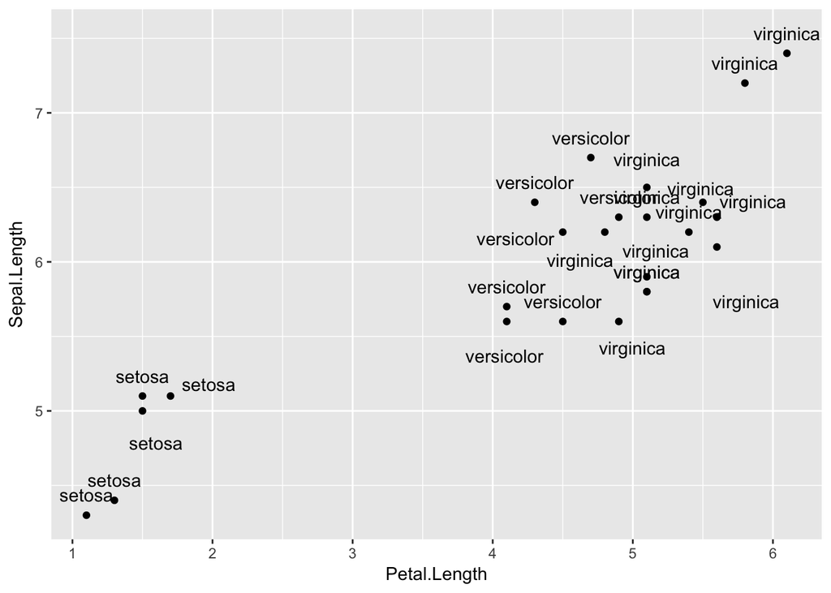

```r
labels <- read.csv("irisPoints.csv")
g1 <- ggplot() +
  geom_point(data=iris2, aes(x=Petal.Length, y=Sepal.Length)) +
  geom_text(data=labels,
            aes(x=lab_x,
                y=lab_y,
               label=lab))
print(g1)
```

### Interested in other interactive graphics using `hmtlwidgets` ? Lets look at the `networkD3` package

```r
#NetworkD3 creates interactive networks graphics. I am going to show you two.
#Simplenetwork graph
#We need a source and target
source <- c("A", "A", "A", "A",
         "B", "B", "J", "C", "D")
target <- c("B", "C", "D", "J",
            "E", "F", "G", "H", "I")
networkData <- data.frame(source, target)
#plot
simpleNetwork(networkData)
```

[interactive chart not shown]

We can build other, more complicated graphs as well

```r
##We can make even more complicated graphics as well
#Force network graphics
#Using the built in data set "misNodes" and "misLinks"
#based on characters and their interactions from Les Miserables
#Load data
data(MisLinks)
data(MisNodes)
#look real fast- also take up a lot of space

#MisNodes
#MisLinks
#Plot
forceNetwork(Links = MisLinks, Nodes = MisNodes,
            Source = "source", Target = "target",
             Value = "value", NodeID = "name",
             Group = "group", opacity = 0.8)
```

[interactive chart not shown]

```r
#We can also build sanky network graphs as well
sankeyNetwork(Links=MisLinks, Nodes=MisNodes, Source="source",
              Target ="target", Value="value",
              NodeID = "name", fontSize = 12, nodeWidth = 25, height=700, width=1000)
```

[interactive chart not shown]